# Trip Acceleration Segments Part 1

Dave Hurst

Friday, March 6, 2015

Working with just acceleration segments, let’s see what we can figure out.

Using the ‘getAccels’ function, and ‘gen_profiles_by_driver.R’, I’ve got acceleration segment data for several drivers. For now, we’ll load 6 of them, which includes our buddy 2591, the driver we’ll start trying to isolate.

```r
set.seed(2349)
drivers.dir <- dir(data.dir)
random.driver <- order(runif(1:length(drivers.dir), ))
driver.list <- drivers.dir[random.driver]  #needless complication that I'm stuck with at the moment
accels.dir <- "profile_accels"
segs.dir <-  "profile_segs"

driver.id <- driver.list[1]
accels.fn <- get.fname (accels.dir, driver.id, "accels")
load( file=accels.fn )
segs.fn <- get.fname (segs.dir, driver.id, "segs")
load( file=segs.fn )
asegs <- accels  # this is the data frame we'll get all the acceleration data in
gsegs <- trip.seg # this is the data frame we'll get all the geometry data in

for (driver.id in driver.list[2:6]) {
    accels.fn <- get.fname (accels.dir, driver.id, "accels")
    load( file=accels.fn )
    asegs <- rbind(asegs, accels)
    rm(accels)

    segs.fn <- get.fname (segs.dir, driver.id, "segs")
    load( file=segs.fn )
    gsegs <- rbind(gsegs, trip.seg)
    rm(trip.seg)

}
gsegs <- gsegs[ !grepl( "^x.", gsegs$type ), ]  #remove the dead info

head(asegs)
```

```
##    t0  tn     v0     vn  a.mid   a.v5  a.v10  a.v15  a.v20   dist snip.t0
## 1  23  46 9.0498 23.806 0.6763     NA 0.7570 1.3668 0.7561 434.38      21
## 2 129 154 9.6851 24.017 0.6774     NA 0.2448 1.1688 0.8256 460.81     126
## 3 217 251 9.4056 23.968 0.3086     NA 0.4727 0.8110 0.4879 658.70     217
## 4 325 363 6.8682 23.896 0.4905     NA 0.1812 0.8474 0.3668 635.91     323
## 5 547 560 5.6401 16.580 0.7031     NA 1.7984 0.7162     NA 170.44     546
## 6 198 208 0.5927  6.583 1.3849 0.9924     NA     NA     NA  35.18     190
##   snip.tn n.snip first.seg n.strt strt.gap strt.overrun driver trip
## 1     125      2     curve      1        8           79   2591    1
## 2     210      4     curve      1       11           56   2591    1
## 3     322      3     curve      1        8           71   2591    1
## 4     543      4      <NA>      1       NA          180   2591    1
## 5     564      3      turn      1        4            4   2591    1
## 6     212      3      stop      1        7            4   2591    2
```

```r
head(gsegs)
```

```
##    id  t0  tn     type type.id driver tripnum
## 30 30   1   2     <NA>      NA   2591       1
## 31 31   3  20 straight   12001   2591       1
## 13 13  21  30    curve    5001   2591       1
## 32 32  31 125 straight   14001   2591       1
## 15 15 126 130    curve    5002   2591       1
## 17 17 132 135    curve    5003   2591       1
```

We currently have data loaded for 6 drivers

Q: How many acceleration segments do we have by velocity threshold  
A: (a.mid has 100% coverage)

```
## a.mid  a.v5 a.v10 a.v15 a.v20
##  8028  5361  5336  2571   791
```

```
## by percentage:
```

```
##  a.v5 a.v10 a.v15 a.v20
##  66.8  66.5  32.0   9.9
```

Plotting the first segment, we see a curve onto a relatively long straight. Here are plots through the straight way, and just beyond the accleration. (note the acceleration phase continues, except for a brief deceleration (gear shift?)).

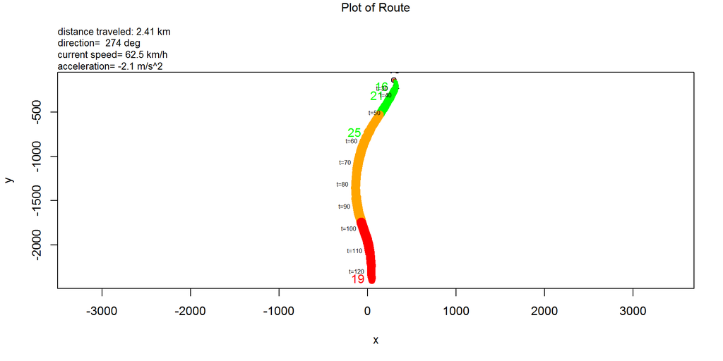

```r
trip <- getTrip( 2591, 1)
plotTrip( trip , tmin=21, tmax=125, t.mark=10)
```

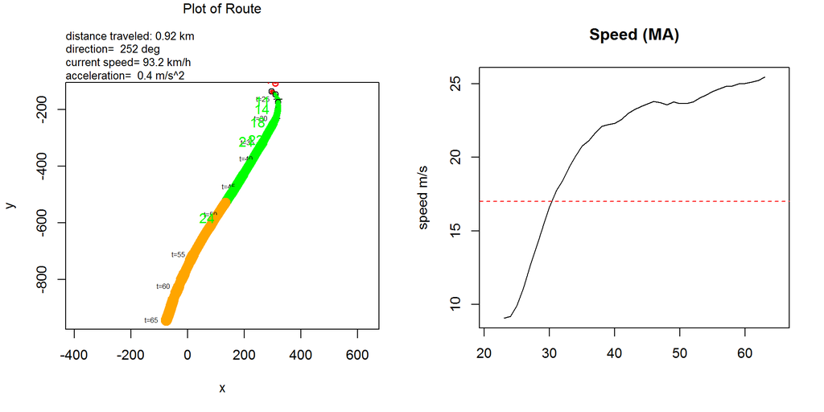

```r
plotTripSegment( trip , tmin=21, tmax=65, t.mark=5, v.mark=2)
```

Q: How many acceleration segments are limited to just 1 or 2 geographical segments and with a straight segment that goes beyond the end of the acceleration by at least 5 seconds?

A:

```r
xx <- with(asegs, asegs[ n.snip <= 2 & strt.overrun >= 5, ])
nrow(xx)
```

```
## [1] 1584
```

```r
#what's the number by driver?
table(xx$driver)
```

```
##
## 1154 1598 2041 2136 2591 3305
##  227  298  192  359  258  250
```

This looks like enough to do things with by itself. Let’s repeat the velocity threshold question for this subset. Q: How many acceleration segments do we have by velocity threshold  
A:

```
## a.mid  a.v5 a.v10 a.v15 a.v20
##  1584   367  1043   784   308
```

What’s the next segment look like (From trip 3)

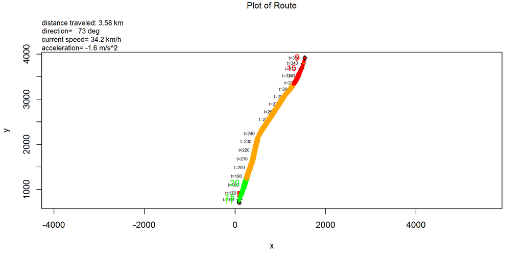

```r
segx <- xx[2,]
trip <- getTrip( segx$driver, segx$trip)
plotTrip( trip , tmin=segx$snip.t0, tmax=segx$snip.tn, t.mark=10)
```

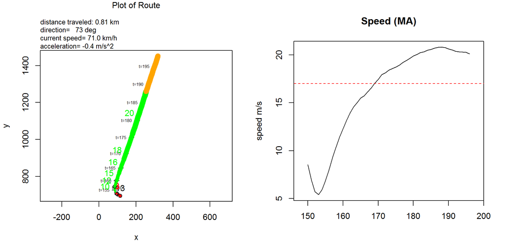

```r
plotTripSegment( trip , tmin=segx$t0-5, tmax=segx$tn+10, t.mark=5, v.mark=2)
```

and the next

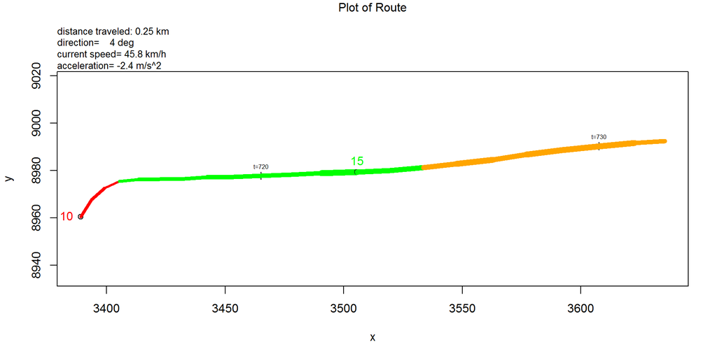

```r
segx <- xx[3,]
trip <- getTrip( segx$driver, segx$trip)
plotTrip( trip , tmin=segx$snip.t0, tmax=segx$snip.tn, t.mark=10)
```

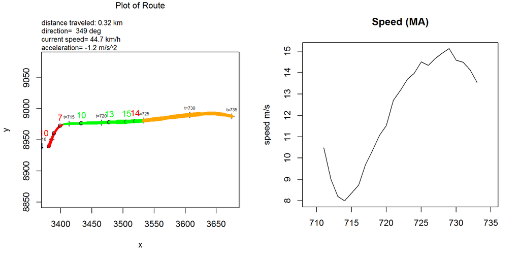

```r
plotTripSegment( trip , tmin=segx$t0-5, tmax=segx$tn+10, t.mark=5, v.mark=2)
```

I think these all look similar enough to move on. Let’s do some EDA on the different features

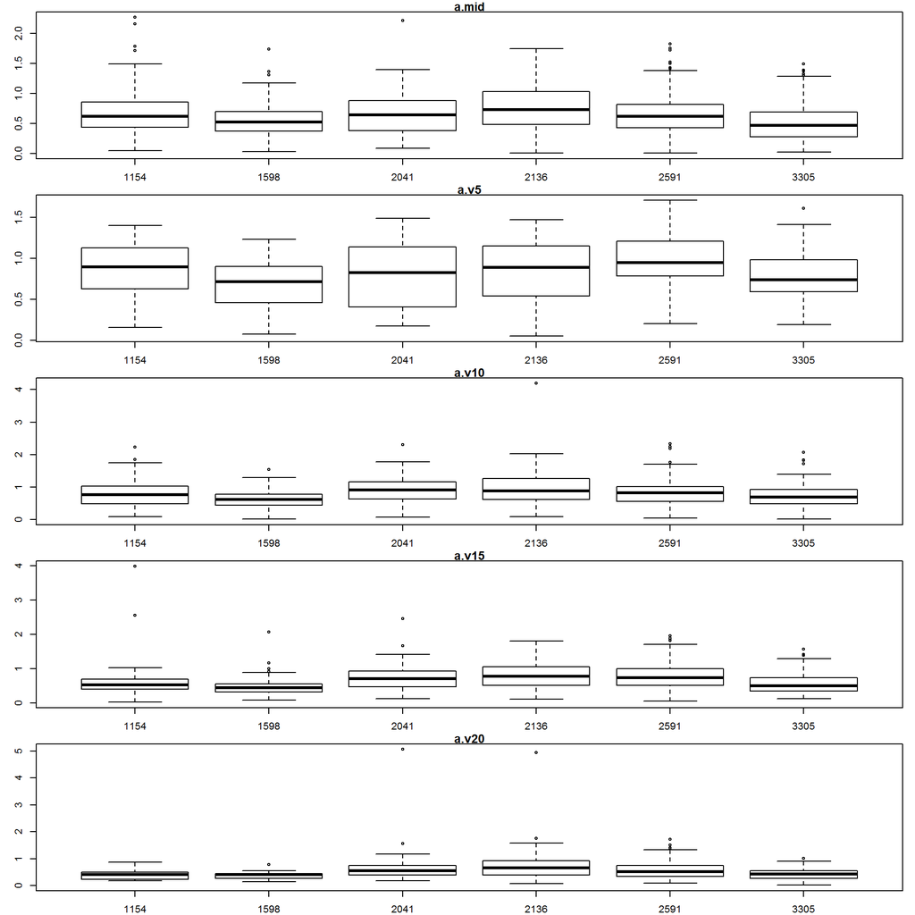

```r
par.orig <- par(mfrow=c(5,1), mar=c(2,3,1,1))
for (i in 5:9) { boxplot( xx[,i] ~ xx$driver, main=colnames(xx)[i]) }
```

```r
par(par.orig)
```

These don’t look terribly differentiated, but there is a weak pattern for the drivers. Let’s try and squeeze a little more juice from the rock:

## Max acceleration for each segment xx)

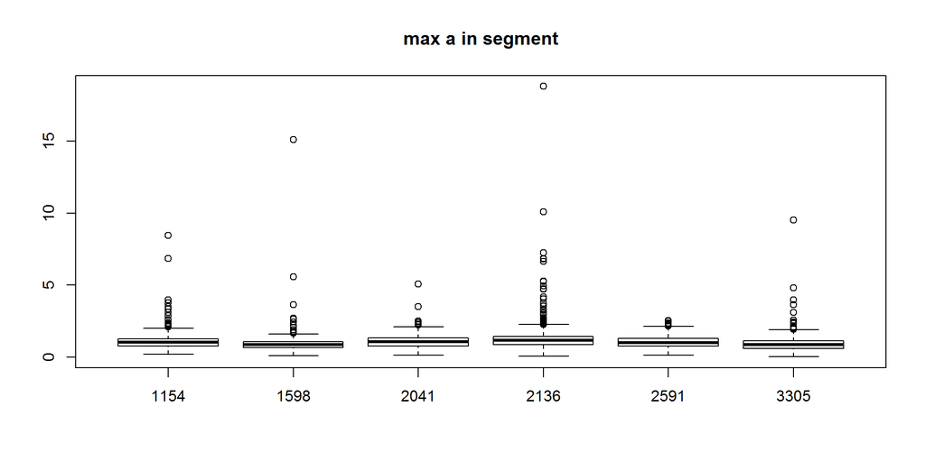

```r
xx$grp <- "xx"
asegs$grp <- "all"
xx.all <- rbind(asegs, xx)
xx.all$maxa <- apply( xx.all[ ,5:9], 1, max, na.rm=TRUE)
xx.all$mina <- apply( xx.all[ ,5:9], 1, min, na.rm=TRUE)
boxplot( xx.all$maxa ~ xx.all$driver, main="max a in segment")
```

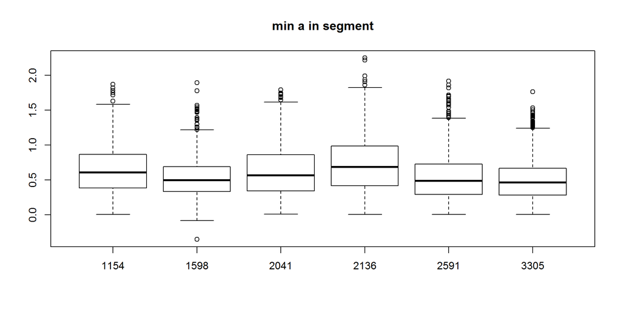

```r
boxplot( xx.all$mina ~ xx.all$driver, main="min a in segment")
```